# Estimates of molecular convergence reveal genes with intermediate pleiotropy underlying adaptive variation across teleost fish - Report

### Phenotype plots

The plot shows the distribution of phenotype keyword terms and the frequency of affected phenotype terms from ZFIN. Panel on the left shows the effect of genetic perturbation on the convergent genes. Panel on the right shows the number of unique affected structures that show a phenotype after genetic perturbation. The data shows that mutations in the convergent genes can affect several phenotypes and structures, with a majority of the effects showing a decrease or reduction in affected structures or processes, while a few shows an increase.

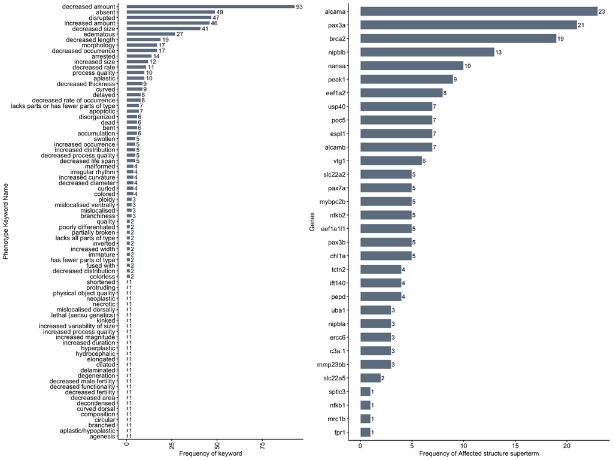

```r
ph_dat<-pheno_conv %>% summarise(n = n(),.by = c(`Phenotype Keyword Name`)) %>% mutate(`Phenotype Keyword Name`=reorder(`Phenotype Keyword Name`,n))
g1<-ggpubr::ggbarplot(ph_dat, y = "Phenotype Keyword Name", x = "n",
                  x.text.angle = 90,
                  fill = "#708090",
                  color = "white",
                  xlab = "Frequency of keyword")+
    geom_text(aes(label = n), hjust = -0.2)


read_tsv("./Datasets/DatasetS0_csv_files/phenoGeneCleanData_fish_2023.05.07.tsv")->pheno #Download from ZFIN
#ph_c<-pheno %>% filter(`Gene Symbol` %in% pheno_conv$`Gene name`)
ph_c<-pheno %>% filter(`Gene Symbol` %in% pheno_conv$`Gene name`) %>% dplyr::select(`Gene Symbol`,`Affected Structure or Process 1 superterm ID`) %>%
  na.omit() %>% distinct(`Affected Structure or Process 1 superterm ID`,.keep_all = T) %>%
  summarise(n = n(),.by = c(`Gene Symbol`)) %>%
  mutate(type = "convergent") %>% arrange(desc(n))


make_pheno_terms_dist<-function(d){
  pheno %>% filter(`Gene Symbol` == d) %>% distinct(`Affected Structure or Process 1 superterm ID`,.keep_all = T) %>%
  summarise(n = n(),.by = c(`Affected Structure or Process 1 superterm Name`,`Publication ID`)) %>% mutate(Gene_symbol = d)
}

purrr::map(ph_c$`Gene Symbol`,make_pheno_terms_dist) %>% bind_rows() %>%
  dplyr::select(Gene_symbol,`Affected Structure or Process 1 superterm Name`) %>%
  summarise(n = n(),.by = c(Gene_symbol))->ph_c

ph_c$Gene_symbol<-factor(ph_c$Gene_symbol,levels = c(ph_c %>% arrange((n)) %>% pull(Gene_symbol)))
g2<-ggpubr::ggbarplot(ph_c,y = "Gene_symbol",
                      x = "n",
                      fill = "#708090",
                      color = "white",
                      x.text.angle = 0,
                      xlab = "Frequency of Affected structure superterm",
                      ylab = "Genes")+
  geom_text(aes(label = n), hjust = -0.1)

ggpubr::ggarrange(g1,g2)
```

The chord diagram shows that for some genes the perturbation phenotypes occur across multiple tissue systems (e.g. alcama, pax3a). The length of the grey bars correspond to the frequency values in the bar plot.

```r
library(circlize)
pheno_terms<-read_csv("./Datasets/DatasetS0_csv_files/Pheno_terms_table_revised.csv")
pheno_terms %>% summarise(n = n(),.by = c(`Gene Symbol`,tissue_system))
```

| Gene Symbol | tissue_system | n |
| --- | --- | --- |
| alcama | Nervous | 11 |
| alcama | Skeletal | 6 |
| alcama | Circulatory | 5 |
| alcama | Whole organism | 1 |
| alcama | Digestive | 1 |
| alcamb | Nervous | 6 |
| alcamb | Embryo | 1 |
| arid1b | Whole organism | 2 |
| brca2 | Whole organism | 1 |
| brca2 | Nervous | 6 |

[output cut: 96 more lines]

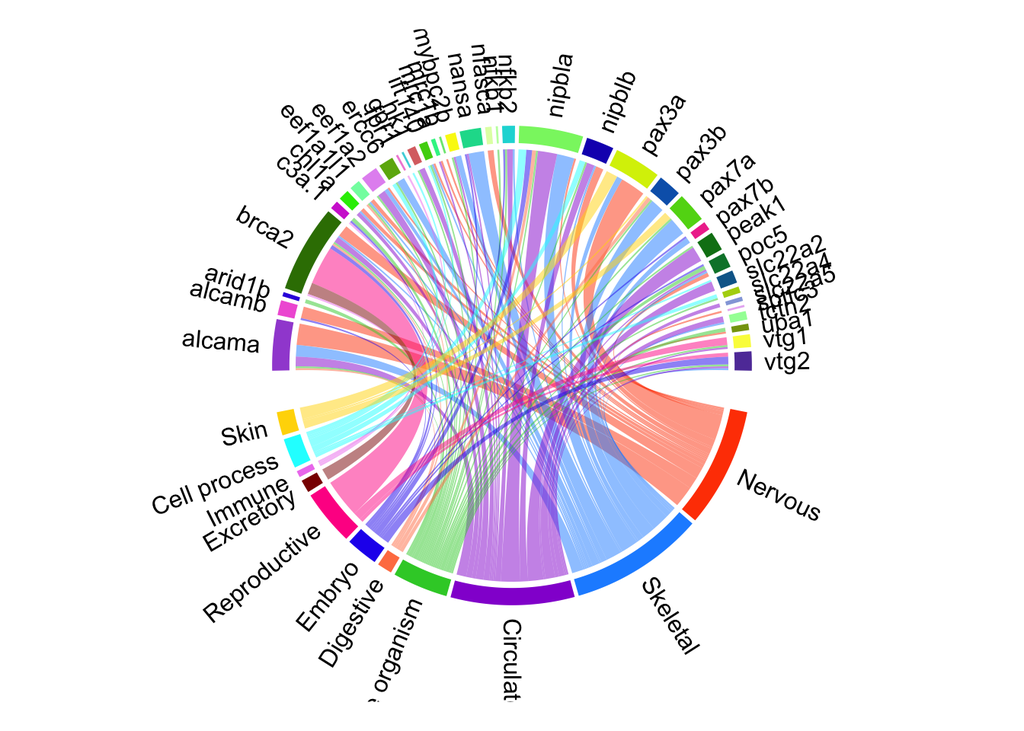

```r
pheno_terms_wide<-pheno_terms %>% summarise(n = n(),.by = c(`Gene Symbol`,tissue_system)) %>%
  pivot_wider(names_from = `Gene Symbol`, values_from = n)
pheno_terms_wide[is.na(pheno_terms_wide)]=0

df_matrix <- pheno_terms_wide %>%
  select(-tissue_system) %>%  # Remove the Gene_symbol column
  as.matrix()

rownames(df_matrix)<-pheno_terms_wide$tissue_system

tissue_colors_vibrant <- c(
  "Nervous" = "#FF4500",      # Orange Red
  "Skeletal" = "#1E90FF",     # Dodger Blue
  "Circulatory" = "#9400D3",  # Dark Violet
  "Whole organism" = "#32CD32", # Lime Green
  "Digestive" = "#FF7F50",    # Coral
  "Embryo"= "#2611EE",        # Dark Navy
  "Skin" = "#FFD700",         # Gold
  "Excretory" = "#8B0000",    # Dark Red
  "Reproductive" = "#FF1493", # Deep Pink
  "Cell process" = "#00FFFF", # Cyan
  "Immune" = "#EE82EE"     # Violet
)


chordDiagram(df_matrix,
             annotationTrack = "grid",
             preAllocateTracks = 1,grid.col = tissue_colors_vibrant)

# Add labels for each tissue
circos.trackPlotRegion(track.index = 1, panel.fun = function(x, y) {
  tissue = CELL_META$sector.index
  circos.text(CELL_META$xcenter, CELL_META$ylim[1] + .1, tissue,
              facing = "clockwise", niceFacing = TRUE, adj = c(0, 0.5))
}, bg.border = NA)
```

### Comparing the distributions

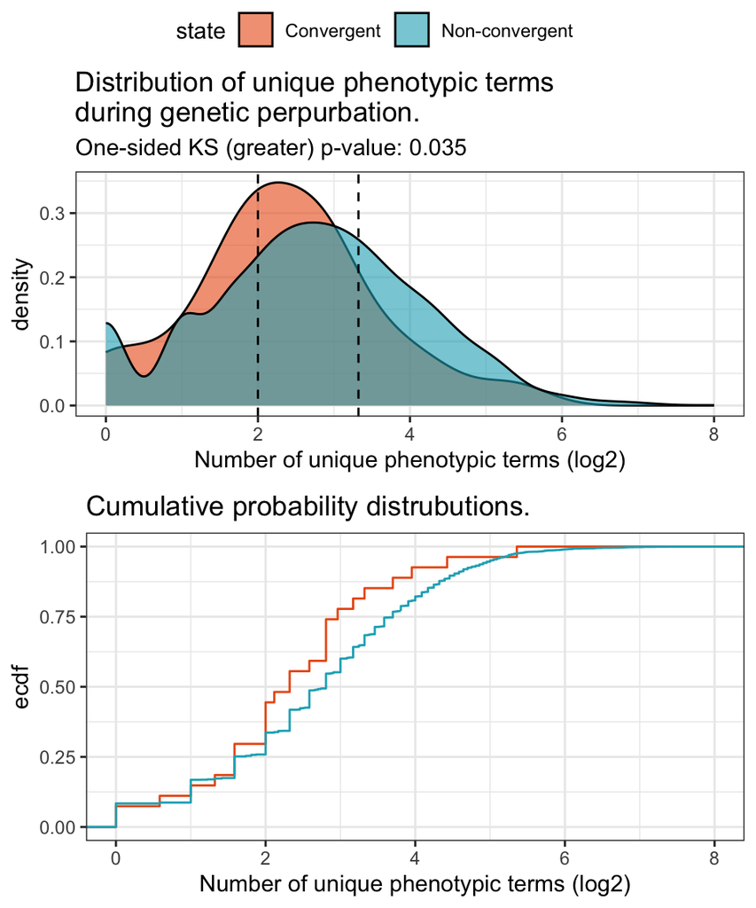

```r
#Load all the data
tau_dat_all<-readRDS("./RDS/tau_dat_all.rds")
read_csv("./Datasets/DatasetS0_csv_files/Danio_biomart.csv")->Danio_biomart
danio_conv<-read.csv("./Datasets/DatasetS0_csv_files/Danio_rerio_convergent_genes.csv")
read_tsv("./Datasets/DatasetS0_csv_files/phenoGeneCleanData_fish_2023.05.07.tsv")->pheno
#Takes a long time
#pheno2 %>% mutate(Gene_symbol=str_extract(rem_str, paste(Danio_biomart$`Gene name`, collapse = "|")))->pheno2
#pheno2 %>% dplyr::rename("Gene Symbol"="Gene_symbol")->pheno2
#pheno2 %>% saveRDS("./RDS/pheno_with_clean_gene_symbol.rds")
readRDS("./RDS/pheno_with_clean_gene_symbol.rds")->pheno2

rbind(pheno %>% dplyr::select(c(`Gene Symbol`, `Affected Structure or Process 1 superterm ID`, `Publication ID`,`Affected Structure or Process 1 superterm Name`)),
      pheno2 %>%  dplyr::select(c(`Gene Symbol`, `Affected Structure or Process 1 superterm ID`, `Publication ID`,`Affected Structure or Process 1 superterm Name`))) %>%
    group_by(`Gene Symbol`) %>% na.omit() %>%
    mutate(uniq_affected_terms=length(unique(`Affected Structure or Process 1 superterm ID`)),
           uniq_pubs=length(unique(`Publication ID`))) %>% distinct(`Gene Symbol`, .keep_all = T)->pheno_summary

inner_join(
Danio_biomart %>% dplyr::select(`Gene stable ID`,`Gene name`,`Gene description`) %>% dplyr::rename("Gene.ID"=`Gene stable ID`,"Gene Symbol"=`Gene name`),
pheno_summary,by = "Gene Symbol") %>% na.omit() %>% distinct(Gene.ID,.keep_all = T)->pheno_summary

#inner_join(pheno_summary,
#estimated_ts_conv_Danio_tau_conv_all %>% dplyr::select(Gene.ID, conv), by = "Gene.ID")->pheno_summary

inner_join(pheno_summary,
           orth_list %>% dplyr::select(Orthogroup,orths) %>% dplyr::rename("Gene.ID"=orths),
           by="Gene.ID") %>%
  dplyr::select(Gene.ID,Orthogroup,everything())->pheno_summary

#Summarise the average number of affected phenotypic terms by Orthogroup
#because each orthogroup has different genes with reporting of phenotypes
#Look at the above pheno_summary data and compare with the Danio_biomart df.

rbind(
  pheno_summary %>% summarise(n=mean(uniq_affected_terms),.by = c("Orthogroup")) %>% filter(Orthogroup %in% non_spuroius_conv$Orthogroup) %>% mutate(state="Convergent"),
  pheno_summary %>% summarise(n=mean(uniq_affected_terms),.by = c("Orthogroup")) %>% filter(!Orthogroup %in% non_spuroius_conv$Orthogroup) %>% mutate(state="Non-convergent"))->pheno_test_dat

q1<-quantile(log2(pheno_test_dat$n),.33)
q2<-quantile(log2(pheno_test_dat$n),.66)

pheno_test_dat %>%
  ggplot(aes(x=log2(n), fill=state))+
  geom_density(alpha=0.6)+
  scale_fill_manual(values = c("#EA5B15","#1AAEC0"))+
  theme_bw()+
  geom_vline(xintercept = q1, linetype="dashed")+
  geom_vline(xintercept = q2, linetype="dashed")+
  xlab("Number of unique phenotypic terms (log2)")+
  labs(title = "Distribution of unique phenotypic terms\nduring genetic perpurbation.",
       subtitle = paste0("One-sided KS (greater) p-value: ",
       signif((ksboot(x=pheno_test_dat %>% filter(state=="Convergent") %>% pull(n),
        y=pheno_test_dat %>% filter(state=="Non-convergent") %>% pull(n),
        alternative = "greater"))$ksboot.pvalue, digits = 4)))->dist_mutant_phenotypes

pheno_test_dat %>%
  ggplot(aes(x=log2(n), color = state))+
  stat_ecdf()+
  scale_color_manual(values = c("#EA5B15","#1AAEC0"))+
  theme_bw()+
  xlab("Number of unique phenotypic terms (log2)")+
  labs(title = "Cumulative probability distrubutions.")->ecdf_mutant_phenotypes

ggarrange(dist_mutant_phenotypes,ecdf_mutant_phenotypes, ncol = 1, common.legend = T)
```

## Pleiotropic release model

To reconcile our observation of multiple convergent substitutions in genes with intermediate levels of pleiotropy across distantly related fish species we introduce the pleiotropic release (PR) model (Fig 7A in main text). To test the PR model’s predictions, we use an evolutionary modeling approach based on Fisher’s geometric model (FGM). Using a distribution of pleiotropy derived from empirical data, we ran adaptive walks using two widely used evolutionary regimes: Strong Selection, Weak Mutation (SSWM) Regime, where mutations are rare but, when they occur, strong selection ensures the fixation of beneficial mutations and the loss of deleterious mutations. And the Greedy Adaptive Walk Regime, where multiple mutations arise (e.g., due to an increase in population size) and the mutation with the highest fitness advantage fixes in the population. The results of the adaptive walks showed that in the SSWM regime, the pleiotropy distribution of fixed mutations closely mirrored that of all mutations that arose, with slightly lower mean pleiotropy among fixed mutations, as expected due to limited mutation availability. In contrast, under the greedy walk regime, the pleiotropy distribution of fixed mutations shifted, favoring mutations with intermediate pleiotropy (Fig 7B). This suggests that in a mutation-rich environment, genes with intermediate pleiotropy play a crucial role in early adaptation to ecological changes. Code used to run the model can be found in the Scripts folder in the online repository in Zenodo.

### Load the data

```r
#File paths
files<-list.files(path = paste0("./Pleiotropy_data"), pattern = "\\.csv$", full.names = TRUE, recursive = TRUE)

#Sim types
scaled<-files[str_detect(files,"scaled")]
not_scaled<-files[str_detect(files,"scaled",negate = T)]

##Not scaled
sswm.not_scaled<-not_scaled[str_detect(not_scaled,"SSWM")]
greedy.not_scaled<-not_scaled[str_detect(not_scaled,"greedy")]

sim_features_greedy_sswm_not_scaled<-function(file_name){
  #Sim features for greedy and SSWM
  regime<-str_split(file_name,"_",simplify = T)[,2] %>% str_remove("data/")
  type_of_mut<-str_split(file_name,"_",simplify = T)[,3]
  dist<-str_split(file_name,"_",simplify = T)[,5] %>% str_remove("dist=")
  ntraits<-str_split(file_name,"_",simplify = T)[,6] %>% str_remove("ntraits=")

  read.csv(file_name, col.names = "P") %>% mutate(regime=regime, type_of_mut=type_of_mut, dist=dist, ntraits,ntraits) %>%
    as.data.frame() %>% return()
}


purrr::map(sswm.not_scaled,
           sim_features_greedy_sswm_not_scaled) %>% list_rbind()->sswm.not_scaled_out


purrr::map(greedy.not_scaled,
           sim_features_greedy_sswm_not_scaled) %>% list_rbind()->greedy.not_scaled_out
```

### L distribution

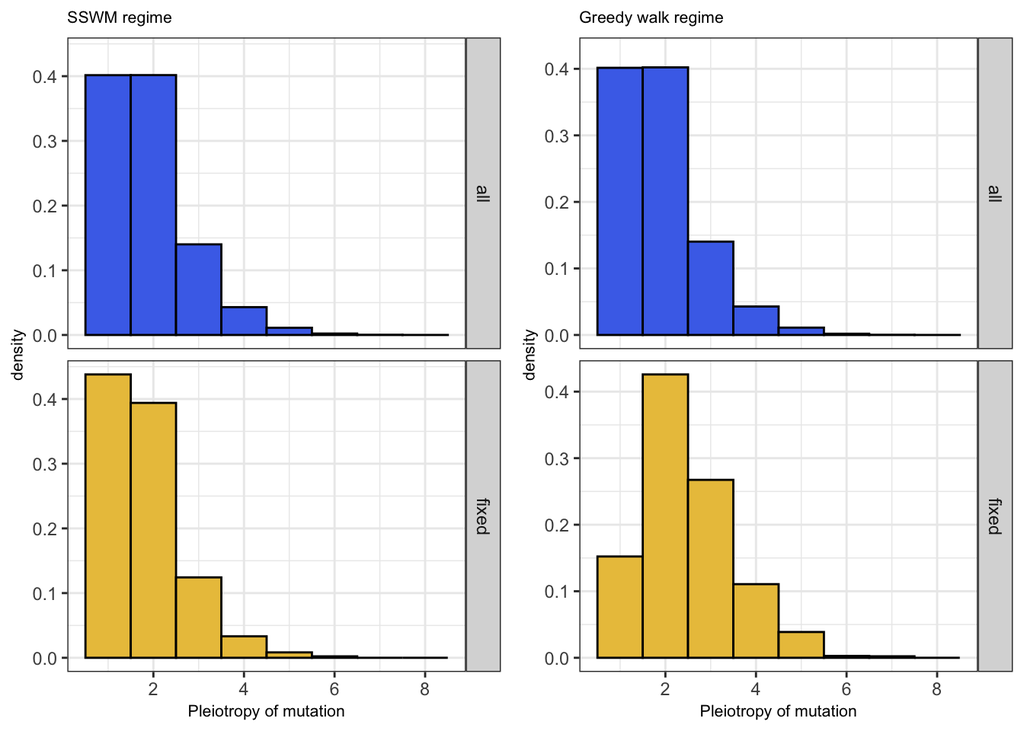

```r
##Unscaled plots
sswm.not_scaled_out %>% filter(dist=="L") %>% filter(ntraits==10) %>%
  ggplot(aes(x=P, fill = type_of_mut, y=after_stat(density)))+
  facet_grid(rows=vars(type_of_mut))+
  geom_histogram(color="black", binwidth = 1)+
  scale_fill_manual(values = c("#4A72EA","#EAC34A"))+
  labs(title = "SSWM regime")+
  xlab("Pleiotropy of mutation")+
  theme_bw()+
  theme(legend.position = "none",
        plot.title = element_text(size = 8),
        axis.title = element_text(size = 8))->sswm_not_scaled_L

greedy.not_scaled_out %>% filter(dist=="L") %>% filter(ntraits==10) %>%
  ggplot(aes(x=P, fill = type_of_mut, y=after_stat(density)))+
  facet_grid(rows=vars(type_of_mut))+
  geom_histogram(color="black", binwidth = 1)+
  scale_fill_manual(values = c("#4A72EA","#EAC34A"))+
  labs(title = "Greedy walk regime")+
  xlab("Pleiotropy of mutation")+
  theme_bw()+
  theme(legend.position = "none",
        plot.title = element_text(size = 8),
        axis.title = element_text(size = 8))->greedy_not_scaled_L


ggpubr::ggarrange(sswm_not_scaled_L, greedy_not_scaled_L, ncol = 2)
```

```r
kldtools::ksboot(x = greedy.not_scaled_out %>% filter(dist=="L") %>% filter(ntraits==10) %>% filter(type_of_mut=="all") %>% pull(P),
        y = greedy.not_scaled_out %>% filter(dist=="L") %>% filter(ntraits==10) %>% filter(type_of_mut=="fixed") %>% pull(P), alternative = "greater",nboots = 1000)
```

```
## $ksboot.pvalue
## [1] 0
##
## $nboots
## [1] 1000
```

### Reverse L

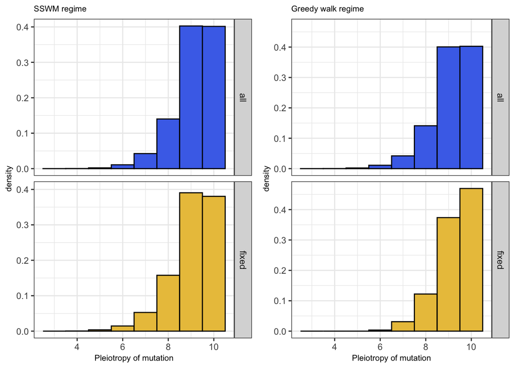

```r
##Other distributions
#Reverse L
sswm.not_scaled_out %>% filter(dist=="rev.L") %>% filter(ntraits==10) %>%
  ggplot(aes(x=P, fill = type_of_mut, y=..density..))+
  facet_grid(rows=vars(type_of_mut))+
  geom_histogram(color="black", binwidth = 1)+
  scale_fill_manual(values = c("#4A72EA","#EAC34A"))+
  labs(title = "SSWM regime")+
  xlab("Pleiotropy of mutation")+
  theme_bw()+
  theme(legend.position = "none",
        plot.title = element_text(size = 8),
        axis.title = element_text(size = 8))->sswm_not_scaled_rev.L

greedy.not_scaled_out %>% filter(dist=="rev.L") %>% filter(ntraits==10) %>%
  ggplot(aes(x=P, fill = type_of_mut, y=..density..))+
  facet_grid(rows=vars(type_of_mut))+
  geom_histogram(color="black", binwidth = 1)+
  scale_fill_manual(values = c("#4A72EA","#EAC34A"))+
  labs(title = "Greedy walk regime")+
  xlab("Pleiotropy of mutation")+
  theme_bw()+
  theme(legend.position = "none",
        plot.title = element_text(size = 8),
        axis.title = element_text(size = 8))->greedy_not_scaled_rev.L

ggpubr::ggarrange(sswm_not_scaled_rev.L, greedy_not_scaled_rev.L, ncol = 2)
```

### Uniform

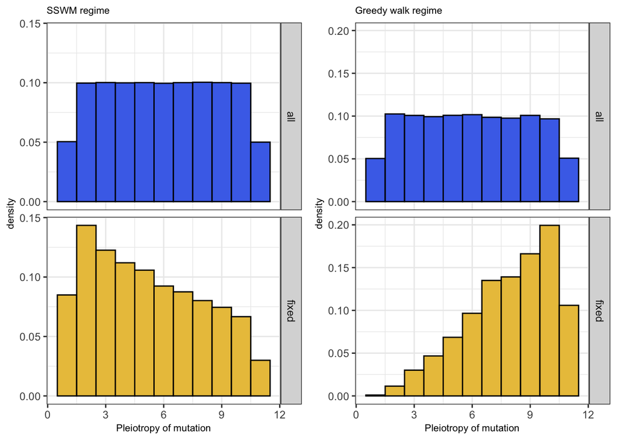

```r
sswm.not_scaled_out %>% filter(dist=="uni") %>% filter(ntraits==10) %>%
  ggplot(aes(x=P, fill = type_of_mut, y=..density..))+
  facet_grid(rows=vars(type_of_mut))+
  geom_histogram(color="black", binwidth = 1)+
  scale_fill_manual(values = c("#4A72EA","#EAC34A"))+
  labs(title = "SSWM regime")+
  xlab("Pleiotropy of mutation")+
  theme_bw()+
  theme(legend.position = "none",
        plot.title = element_text(size = 8),
        axis.title = element_text(size = 8))->sswm_not_scaled_uni

greedy.not_scaled_out %>% filter(dist=="uni") %>% filter(ntraits==10) %>%
  ggplot(aes(x=P, fill = type_of_mut, y=..density..))+
  facet_grid(rows=vars(type_of_mut))+
  geom_histogram(color="black", binwidth = 1)+
  scale_fill_manual(values = c("#4A72EA","#EAC34A"))+
  labs(title = "Greedy walk regime")+
  xlab("Pleiotropy of mutation")+
  theme_bw()+
  theme(legend.position = "none",
        plot.title = element_text(size = 8),
        axis.title = element_text(size = 8))->greedy_not_scaled_uni

ggpubr::ggarrange(sswm_not_scaled_uni, greedy_not_scaled_uni, ncol = 2)
```

### All distribution plots

```r
  ggpubr::ggarrange(ggpubr::ggarrange(sswm_not_scaled_L, greedy_not_scaled_L, ncol = 2),
                    ggpubr::ggarrange(sswm_not_scaled_rev.L, greedy_not_scaled_rev.L, ncol = 2),
                    ggpubr::ggarrange(sswm_not_scaled_uni, greedy_not_scaled_uni, ncol = 2),
                    ncol = 1)
```

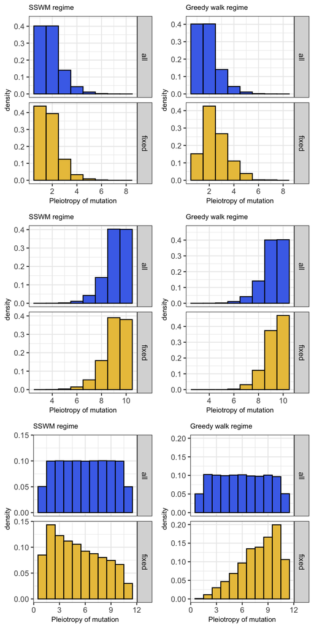